# Testing the ABM using the ACS

H2: Segregation Moderates the Effect of Income Inequality on Housing Inequality

Malte Grönemann

2026-10-28

The second city-level hypothesis tests whether residential segregation moderates the relationship between income inequality and housing cost inequality. High income inequality alone does not mechanically produce dispersed rents and home values: landlords base investment decisions on local neighborhood conditions rather than city-wide income distributions, so the link from income inequality to housing inequality runs through the spatial sorting of households into neighborhoods with different average incomes. While it is straightforward that a larger spread of incomes in a city result in a wider spread of housing quality and prices, my model motivates the new hypothesis that this relationship is moderated by residential segregation. I therefore test the following interaction:

> In more segregated cities, income inequality translates more strongly into inequality in rents and home values.

I therefore expect a **positive** regression coefficient of income inequality on housing cost inequality and a **positive** interaction effect with income segregation.

I derive this hypothesis from the city-level inequality analysis in Part IIIb of the hypotheses experiment. In the simulation, the moderating effect of segregation appears clearly when housing quality is the dependent variable, but not when rent is the dependent variable. This is by design: in the model, rent is monotone in a unit’s utility rank, so its scale is determined entirely by the income distribution and cardinal differences in unit quality never enter rent — only their ordering does. In empirical data, cardinal quality differences are capitalized into rents, so I expect the interaction to emerge with rents / home values as proxies of housing quality.

# Operationalization of Housing Quality Inequality

Housing quality is a multi-dimensional construct, even if the ABM represents it as a single variable. In reality, quality depends on a variety of unit attributes: floor size, number of rooms, appliances and infrastructure, building age and style, and amenities such as a balcony, garden, or fireplace. What constitutes a quality home also varies across households. Rather than constructing an index from such attributes, I use market prices as a proxy. Following the logic of hedonic pricing (Rosen 1974), prices aggregate the value households attach to a unit’s full bundle of attributes (Chau and Chin 2003; Sirmans et al. 2005).

I measure housing cost inequality with a Gini coefficient computed from housing costs pooled across renters and owners within each metro area × year in the PUMS data. Pooling both tenure groups is necessary to capture two distinct dimensions simultaneously: *within-tenure* inequality (the spread of rents among renters, or of values among owners) and the *between-group* gap (the cost difference between renting and owning). A within-tenure analysis would be biased if cities differ in their renter–owner split and if the quality of rental and owner-occupied stock diverges. Because the ABM predicts that segregation translates income inequality into housing inequality by sorting households into differentially desirable neighbourhoods regardless of tenure, the dependent variable should reflect the full cross-tenure distribution of housing costs.

The central measurement challenge is that renters and owners face prices on incompatible scales: monthly contract rent for renters and total market value for owners. I exclude utility costs from both measures, as utility expenditure is a mixed signal — higher water and energy costs can reflect larger homes or poor insulation rather than housing quality. I convert home values to monthly user costs using the metro-level rent-to-price ratio as the capitalization rate. This is a common approximation in the empirical literature on housing costs (Himmelberg, Mayer, and Sinai 2005; Davis, Lehnert, and Martin 2008):

$$u_i = v_i \times \hat{r}_{mt} \;/\;
12,$$

where $v_i$ is the inflation-adjusted home value (`valueh_real`, 1999 USD) and $\hat{r}_{mt}$ is a metro- and wave-specific capitalization rate.

The underlying logic is that in equilibrium a marginal household is indifferent between renting and owning, so the annual rent for a unit equals its owner’s user cost: home value $P$ times a cap rate $r$. The cap rate summarizes the net annual cost of owning per dollar of value — forgone returns on tied-up capital, property taxes, maintenance and depreciation, and a risk premium, less expected appreciation and any tax advantages.

Because it is rarely possible to observe both the rent and the value of the same unit simultaneously, I estimate the cap rate from metro-level medians. Cross-metro variation in $\hat{r}$ is substantively meaningful: the rent-to-price ratio is systematically lower in supply-constrained metros, and I preserve that variation by estimating a cap rate for every metro area in every ACS wave from PUMS weighted median rents and home values (household weight HHWT):

$$\hat{r}_{mt} = 12 \;\times\;
\widetilde{\mathrm{rent}}_{mt} \;/\;
\widetilde{\mathrm{value}}_{mt}.$$

The factor of 12 follows from the real-estate definition of the annual gross yield: $r = \text{annual rent} / \text{value} = 12 \times \text{monthly rent} / \text{value}$. Dividing by 12 in the user-cost formula then recovers a monthly figure, so the two factors cancel and the imputed cost simplifies to

$$u_i = v_i \times
\widetilde{\mathrm{rent}}_{mt} /
\widetilde{\mathrm{value}}_{mt}.$$

**Key assumption.** The formula embeds the assumption that the unit with median rent would sell for the median price, and that this relationship holds proportionally across the full within-metro quality distribution: a home worth twice the median is assumed to rent for twice the median rent. This is unlikely to hold exactly. Not only does the quality of the owner-occupied and rental stock differ, but luxury units also typically command a lower gross yield than entry-level units (the cap rate declines with quality), so the formula overstates imputed costs at the top of the value distribution and understates them at the bottom. The resulting Gini is therefore somewhat inflated relative to the true housing cost distribution. This bias cannot be eliminated without observing what owner-occupied units would rent for in the current market, which is not available in ACS or PUMS. The pooled monthly housing cost is then

$$c_i = \begin{cases} \text{rent\_real}_i
& \text{renter} \\ v_i \times \hat{r}_{mt} \;/\; 12 &
\text{owner,} \end{cases}$$

and the housing cost inequality, my dependent variable, is the HHWT-weighted Gini of $c_i$ within each metro area × year.

# Description of Key Variables

Description of segregation indices can be found in the script for the first city-level hypothesis `SEHTestACS6a_housingseg.Rmd`.

## Income Inequality

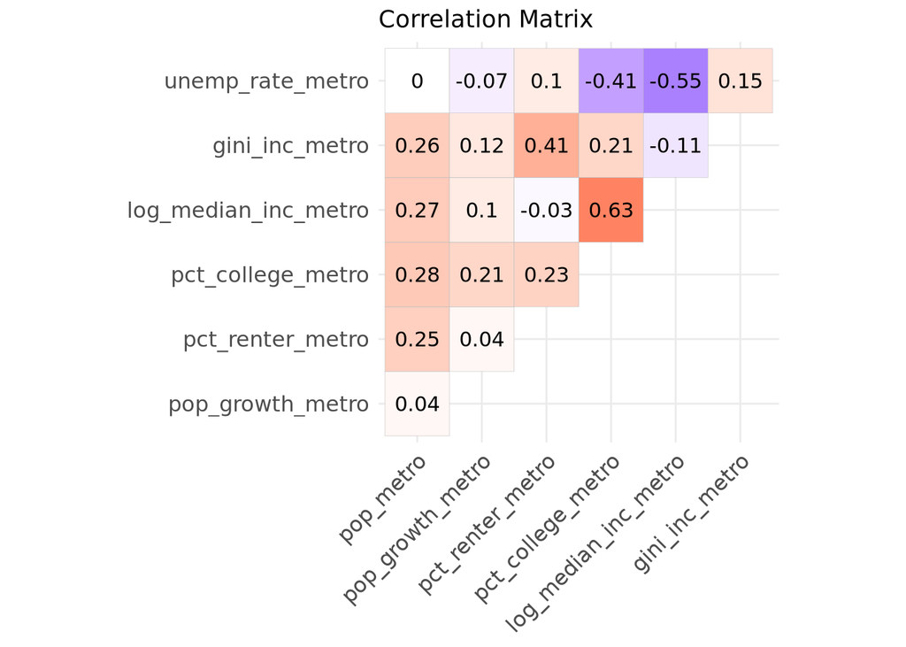

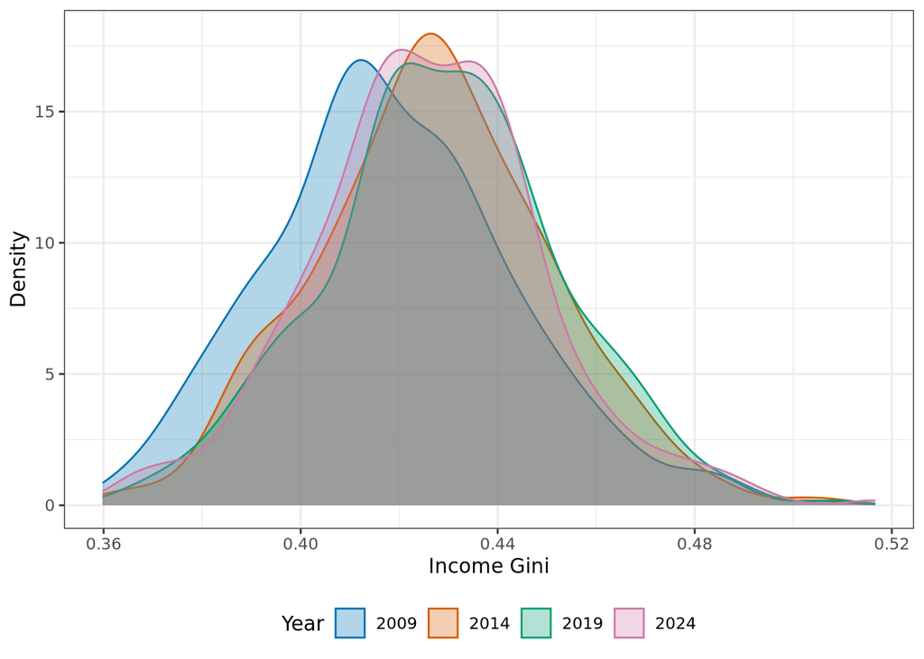

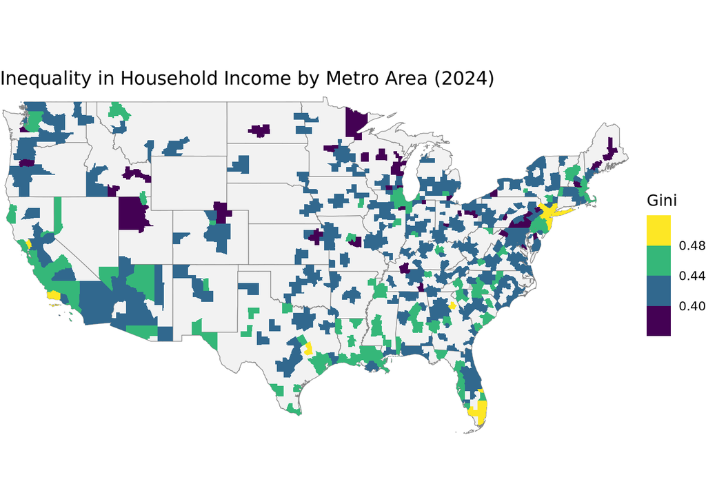

## Housing Cost Inequality

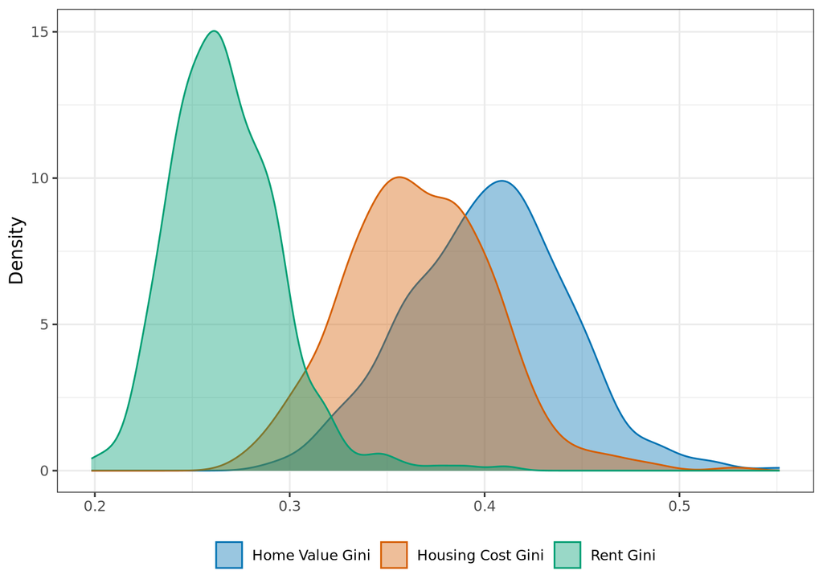

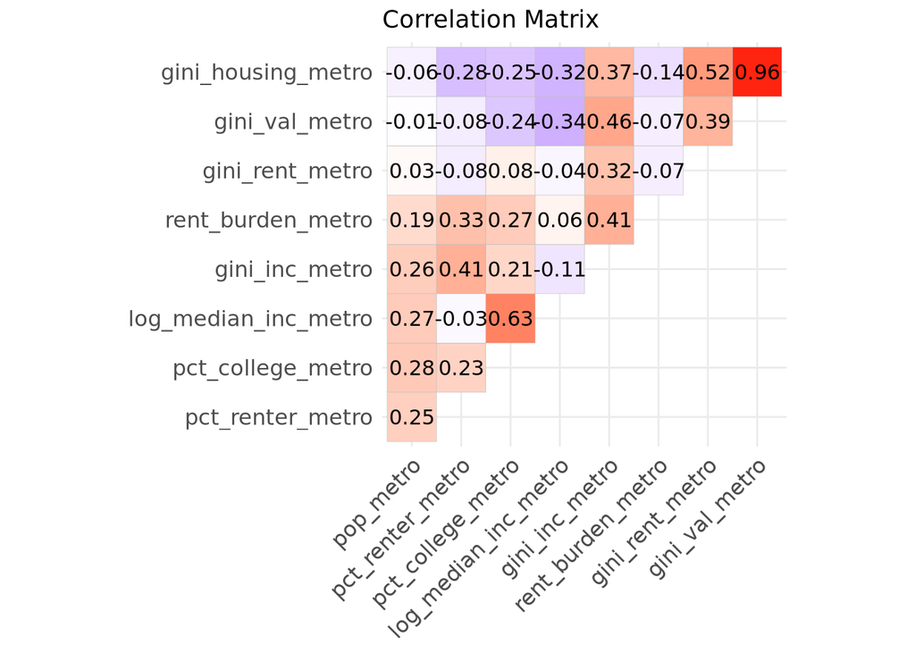

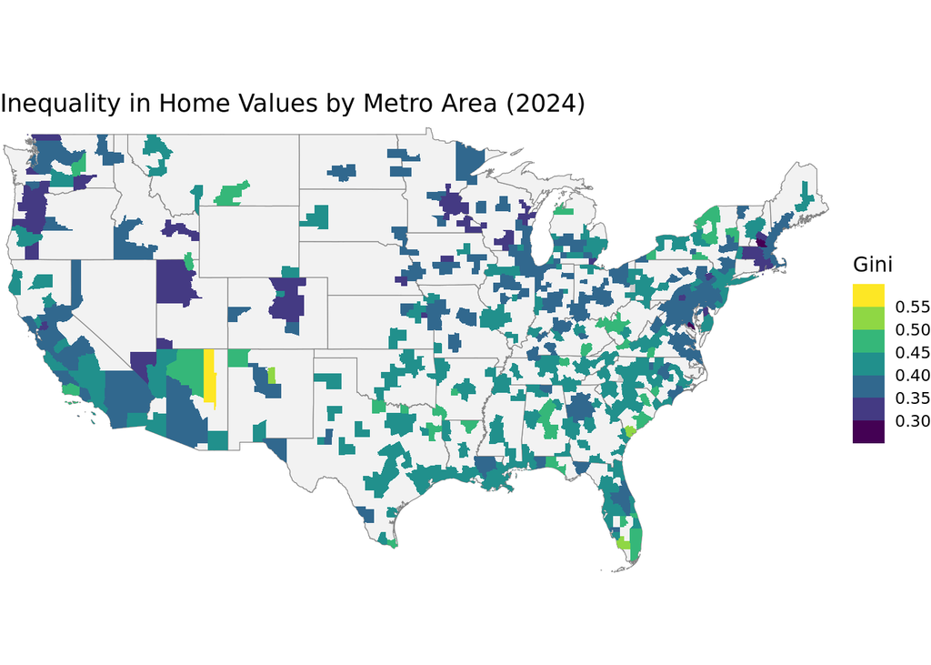

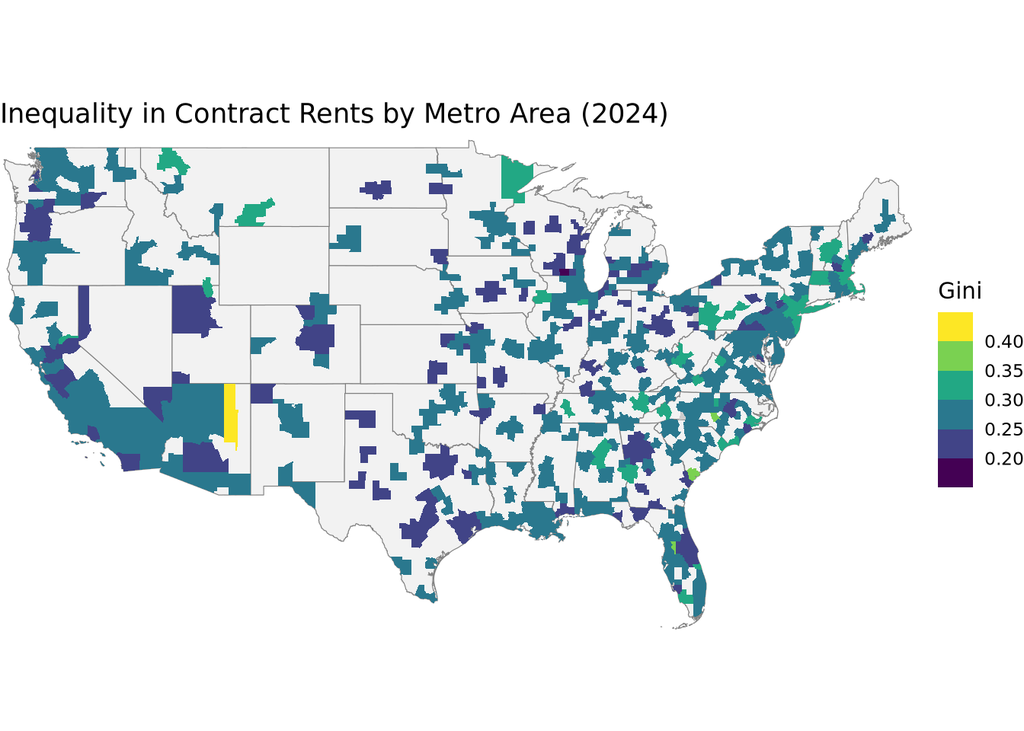

### Combined Housing Cost Gini

The combined housing cost Gini is the dependent variable of the analysis. It pools renters and owners within each metro area × year after converting owner home values to monthly user costs via the metro-specific cap rate (see operationalization above). The pooled distribution captures both within-tenure inequality and the renter–owner cost gap.

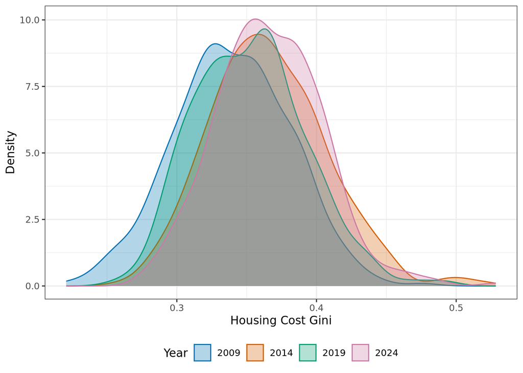

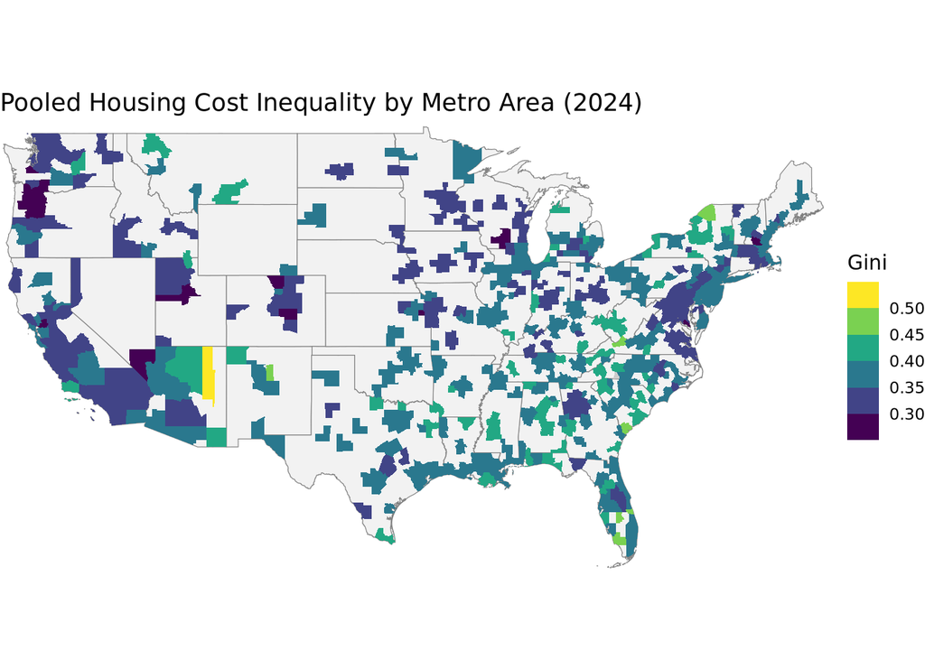

## Period-to-Period Changes

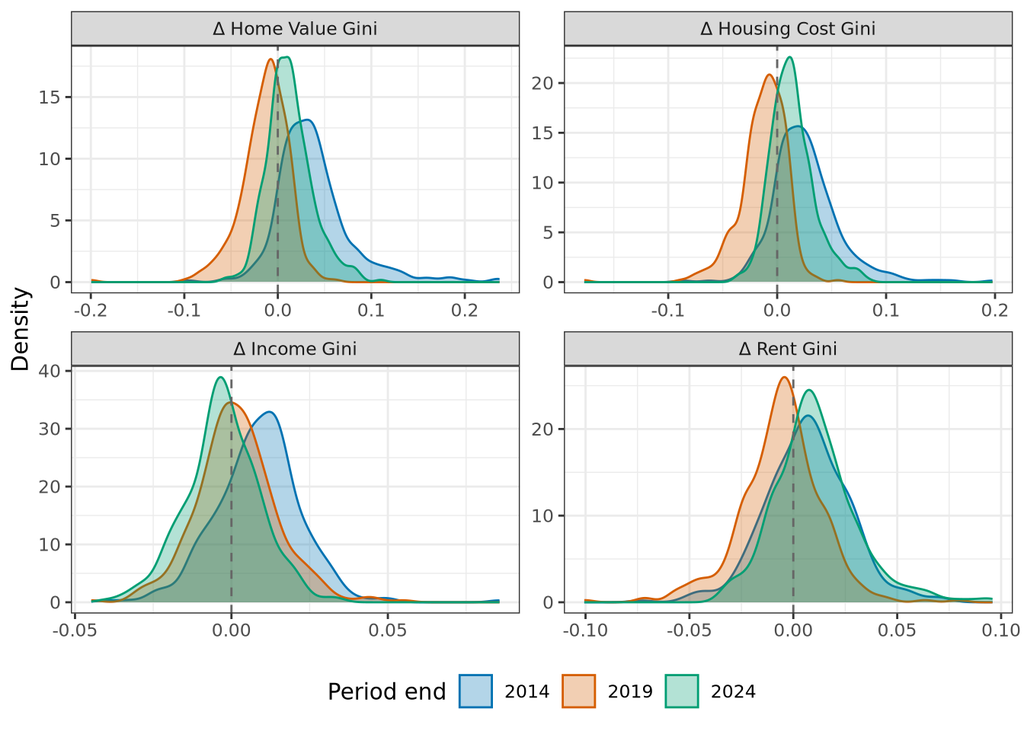

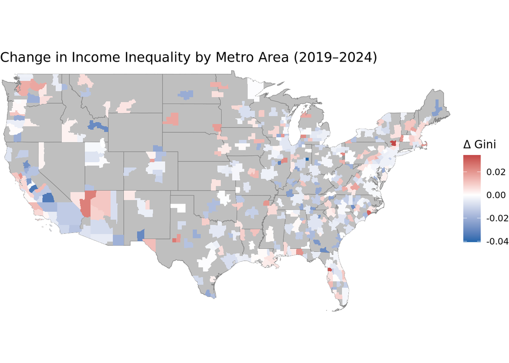

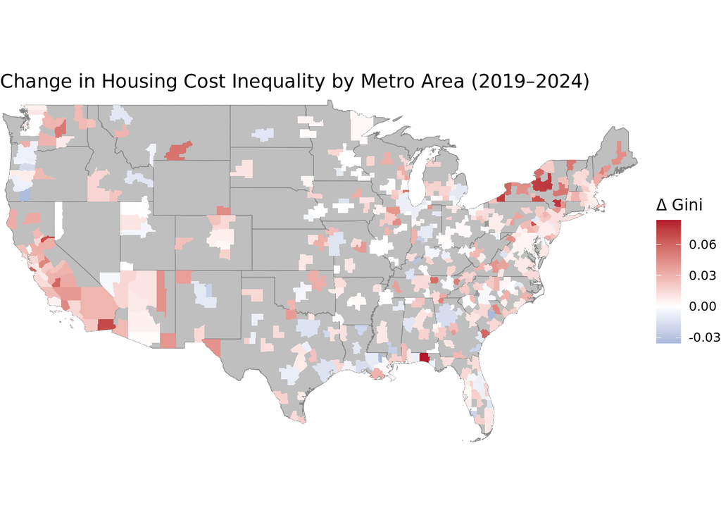

# First-Differences Model

The first-differences (FD) model tests whether a rise in income inequality translates into a larger rise in housing costs in more segregated cities, directly testing the temporal mechanism by which segregation shapes how income inequality propagates through landlord and developer investment decisions.

First-differencing removes all time-constant between-city heterogeneity without requiring unit fixed effects. Three design choices follow from the model. First, the dependent variable and main predictor are differenced ($\Delta$), but income segregation enters as its *lagged level* $H^R_{m,t-5}$: it is the structural context within which income inequality changes play out, it is predetermined relative to $\Delta\text{GiniHousing}$. Second, all time-varying controls enter as period changes ($\Delta$) to match the estimand and absorb demand and economic shocks that could confound the interaction. Third, year fixed effects are retained as two dummies for the three inter-wave difference periods (2009-2014, 2014-2019, 2019-2024) to absorb national trends in housing costs. Standard errors are clustered by metro area only rather than two-way, because the FD sample contains only three period clusters. Income segregation $H^R_{m,t-5}$ is mean-centred so that the main effect of $\Delta\text{GiniInc}$ is evaluated at the average metro.

Although first-differencing removes time-constant confounders, I need to account for alternative mechanisms that could generate the hypothesized pattern. For the interaction effect to be identified, both the independent variable and the moderator need to be conditionally exogenous (Nizalova and Murtazashvili 2016). Because the moderator is a lagged, predetermined level, reverse causality is not a concern for $H^R_{m,t-5}$; the residual threat is that the composition of income inequality growth differs systematically across high- and low-segregation metros in ways that also affect housing cost growth independently of the investment mechanism.

Third, I include two further precautionary controls. The change in renter share accounts for the compositional structure of the pooled housing cost Gini: a shift in the renter–owner mix could mechanically alter the Gini even without any change in within-tenure inequality. The change in vacancy rate captures residual housing market slack not fully absorbed by population growth and unemployment.

The full model therefore estimates the following equation for the change in housing cost inequality in metro area $m$ and period $t$:

$$\Delta\text{GiniHousing}_{m,t} = \alpha
+ \beta_1\,\Delta\text{GiniInc}_{m,t} + \beta_2\,H^R_{m,t-5} +
\beta_3\left(\Delta\text{GiniInc}_{m,t} \times H^R_{m,t-5}\right) +
\boldsymbol{\gamma} \Delta\mathbf{X}_{m,t} + \tau_t +
\varepsilon_{m,t}$$

where $H^R_{m,t-5}$ is lagged income segregation (mean-centred across metros), $\Delta\mathbf{X}_{m,t}$ is the vector of first-differenced controls (population growth, $\Delta$ Hispanic share, $\Delta$ unemployment rate, $\Delta$ racial $H$, $\Delta$ renter share, $\Delta$ vacancy rate), and $\tau_t$ are year fixed effects.

|  | (1) | (2) | (3) | (4) | (5) | (6) |
| --- | --- | --- | --- | --- | --- | --- |
| ΔIncome Gini | 0.351*** | 0.394*** | 0.370*** | 0.375*** | 0.394*** | 0.386*** |
|  | (0.075) | (0.077) | (0.077) | (0.077) | (0.078) | (0.079) |
| Income Segregation Hᴿ (t−5, centred) |  | −0.002 | 0.006 | 0.018 | 0.003 | −0.001 |
|  |  | (0.019) | (0.019) | (0.020) | (0.020) | (0.020) |
| ΔIncome Gini × Hᴿ (t−5) |  | 6.628* | 6.628* | 6.490* | 7.023* | 6.733* |
|  |  | (2.822) | (2.780) | (2.761) | (2.791) | (2.817) |
| ΔPopulation |  |  | −0.106*** | −0.110*** | −0.110*** | −0.115*** |
|  |  |  | (0.013) | (0.013) | (0.013) | (0.014) |
| ΔUnemployment Rate |  |  | 0.240** | 0.236** | 0.246*** | 0.247*** |
|  |  |  | (0.074) | (0.073) | (0.073) | (0.073) |
| ΔHispanic Share |  |  | 0.167* | 0.160* | 0.156* | 0.152* |
|  |  |  | (0.076) | (0.074) | (0.074) | (0.074) |
| ΔMultigroup Racial Segregation H |  |  |  | 0.086+ | 0.100* | 0.108* |
|  |  |  |  | (0.046) | (0.047) | (0.047) |
| ΔIncome Segregation Hᴿ |  |  |  |  | −0.191* | −0.204* |
|  |  |  |  |  | (0.088) | (0.088) |
| ΔRenter Share |  |  |  |  |  | 0.043 |
|  |  |  |  |  |  | (0.057) |
| ΔVacancy Rate |  |  |  |  |  | −0.068 |
|  |  |  |  |  |  | (0.049) |
| Num.Obs. | 1135 | 1135 | 1135 | 1135 | 1135 | 1135 |
| R2 | 0.327 | 0.334 | 0.365 | 0.367 | 0.370 | 0.372 |
| FE: year | X | X | X | X | X | X |

Standard errors clustered by metro area in parentheses.  
+ p < 0.1, * p < 0.05, ** p < 0.01, *** p < 0.001.

The main effect of income inequality changes ($\Delta$Income Gini) on housing cost inequality changes is positive and highly significant. This relationship was expected: a rise in income inequality should lead to a rise in housing cost inequality as households have more unequal budget they can allocate to housing and developers will respond by creating a more varied quality of housing that can be priced accordingly. The interaction between $\Delta$Income Gini and lagged segregation $H^R_{t-5}$ is positive, statistically significant and substantively large, consistent with the theoretical prediction that more segregated cities translate rising income inequality into rising housing cost inequality more strongly because investment decisions by developers are influenced by changes in the local neighborhood. Both coefficients only change marginally when adding control variables. Model 5 adds the change in income segregation which controls for an alternative mechanism for an interaction effect as increases in income inequality increase income segregation and neighborhoods can be priced more unequally but also is an outcome of the spatial investment process. As such, I would have expected that including it reduces the coefficient for the interaction, but contrary to expectation, the coefficient of the interaction effect even increases slightly.

The plot below illustrates the moderation: predicted $\Delta$Housing Cost Gini as a function of $\Delta$Income Gini at three levels of lagged income segregation (low = $-1$ SD, mean = 0, high = $+1$ SD). All other predictors are held at zero (a no-change baseline). Year FE are absorbed. The prediction is based on the total-effect estimate in model 4. The steeper slope for high-segregation metros captures the predicted amplification effect and highlights the substantive size of the interaction.

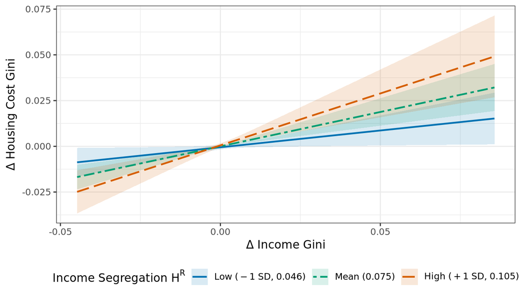

# Robustness Checks

## Cap Rates and Region Fixed Effects

The metro-specific $\hat{r}_{mt}$ could confound the Gini if the rent-to-price ratio itself co-varies with income inequality or segregation, creating a spurious correlation rather than a genuine measurement of housing cost inequality. As the price-to-rent ratio is affected by general conditions of the economy such as interest rates, it is plausible that there is a connection of changes in the cap rate to changes in income inequality. Two alternative cap rate assumptions are therefore carried as robustness checks:

| Variant | Cap rate | What it isolates |
| --- | --- | --- |
| `gini_housing_metro` | Metro×year from PUMS medians | Main specification |
| `gini_housing_metro_5pct` | Fixed 5 % p.a. | Removes all cap rate variation |
| `gini_housing_metro_natl` | Year-specific national rate | Removes cross-metro variation in cap rates |

The two checks address distinct threats to validity. The **fixed 5 % rate** eliminates all variation in the cap rate — both cross-sectional and temporal — so any result that survives cannot be an artefact of cap rate differences between metros or waves. The value of 5 % approximates the pre-boom historical average for the U.S. owner-occupied stock (Davis, Lehnert, and Martin 2008, Loewenstein and Willen 2023). The **national cap rate** retains year-to-year temporal variation but removes cross-metro differences in rent-to-price ratios; if estimates are stable when switching from a metro to a national cap rate, the structural differences between metros is not driving the results.

I also add a model with census division fixed effects. In the differenced equation, these become census division × period dummies that allow each region to have a different average change in housing cost inequality per wave. This absorbs region-specific housing market cycles that year fixed effects alone do not capture. Because the most segregated metros cluster in the Northeast and Midwest, such regional cycles could otherwise create a spurious correlation between lagged segregation and housing cost changes.

I re-estimate FD 4 with the original dependent variable for comparison and exchange the dependent variable in the following models using the same specification.

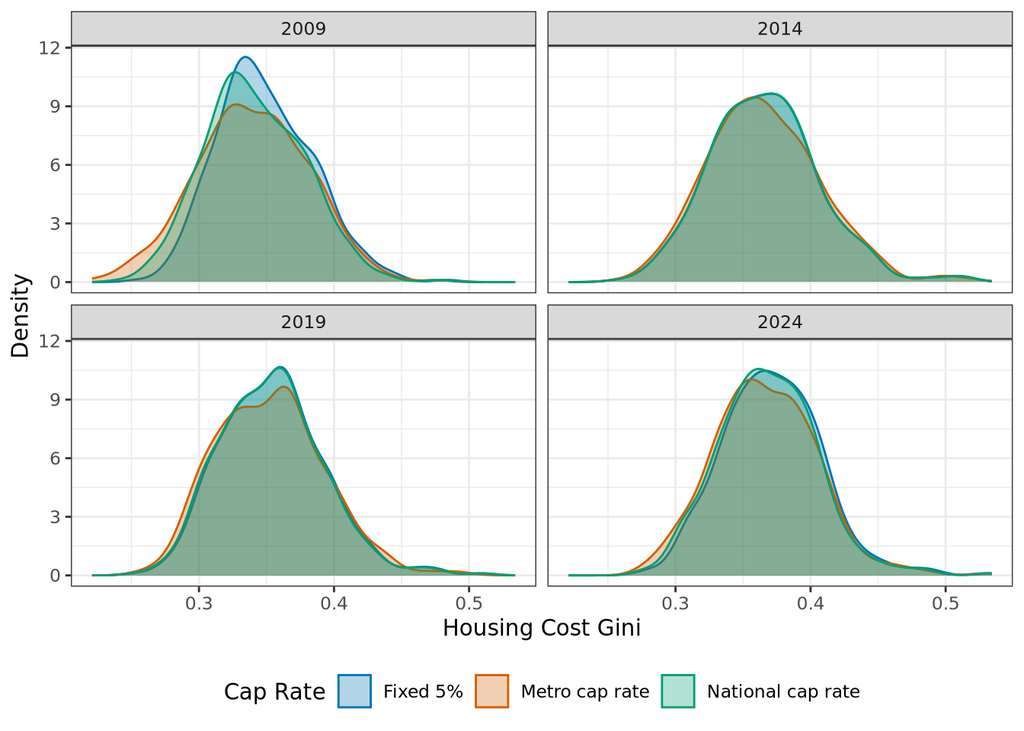

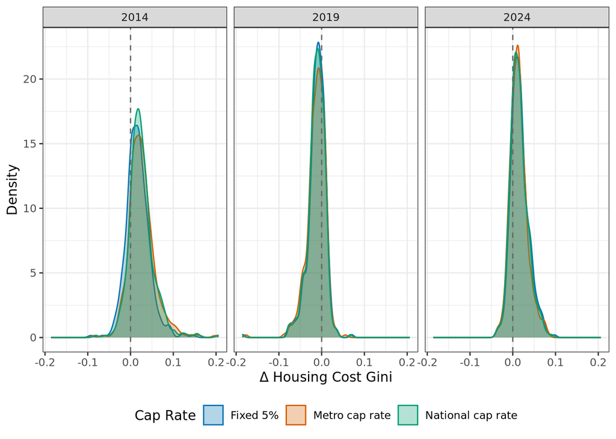

|  | (1) | (2) | (3) | (4) | (5) | (6) |
| --- | --- | --- | --- | --- | --- | --- |
| Dependent Variable | ΔGini Housing (metro) | ΔGini Housing (metro) | ΔGini Housing (5%) | ΔGini Housing (5%) | ΔGini Housing (US) | ΔGini Housing (US) |
| ΔIncome Gini | 0.375*** | 0.367*** | 0.313*** | 0.308*** | 0.347*** | 0.338*** |
|  | (0.077) | (0.078) | (0.082) | (0.083) | (0.083) | (0.083) |
| Income Segregation Hᴿ (t−5, centred) | 0.018 | 0.025 | 0.013 | 0.016 | 0.013 | 0.021 |
|  | (0.020) | (0.020) | (0.019) | (0.020) | (0.019) | (0.020) |
| ΔPopulation | −0.110*** | −0.094*** | −0.089*** | −0.076*** | −0.096*** | −0.083*** |
|  | (0.013) | (0.014) | (0.013) | (0.015) | (0.013) | (0.015) |
| ΔUnemployment Rate | 0.236** | 0.242** | 0.146* | 0.149* | 0.186* | 0.190** |
|  | (0.073) | (0.074) | (0.074) | (0.075) | (0.072) | (0.073) |
| ΔHispanic Share | 0.160* | 0.070 | 0.030 | −0.025 | 0.093 | 0.017 |
|  | (0.074) | (0.079) | (0.065) | (0.076) | (0.070) | (0.077) |
| ΔMultigroup Racial Segregation H | 0.086+ | 0.078+ | 0.063 | 0.061 | 0.087* | 0.075+ |
|  | (0.046) | (0.046) | (0.046) | (0.046) | (0.044) | (0.044) |
| ΔIncome Gini × Hᴿ (t−5) | 6.490* | 6.586* | 5.345+ | 5.397+ | 6.175* | 6.220* |
|  | (2.761) | (2.771) | (2.915) | (2.919) | (2.914) | (2.913) |
| Num.Obs. | 1135 | 1135 | 1135 | 1135 | 1135 | 1135 |
| R2 | 0.367 | 0.379 | 0.283 | 0.290 | 0.355 | 0.367 |
| FE: year | X | X | X | X | X | X |
| FE: census_division |  | X |  | X |  | X |

Standard errors clustered by metro area in parentheses.  
+ p < 0.1, * p < 0.05, ** p < 0.01, *** p < 0.001.

The coefficients for the effect of a change in income inequality changes marginally and remains highly significant in all models. The coefficient for the interaction decreases slightly when using the other cap rate operationalizations and is only significant at the 10 percent level when using the fixed 5 percent cap rate. The sign remains in the expected direction and the estimates remain substantively large though. The addition of census division FE does not change the results, regional trends did not confound the relationship. Taken together, the results for the interaction effect holds across different cap rates and regional controls.

## Decomposition by Tenure

The pooled Gini combines within-tenure inequality with the renter/owner cost gap. To understand which component drives the moderation result, I re-estimate the FD model separately using `d_gini_rent` (renters only) and `d_gini_val` (owners only) as dependent variables. Because these measures are computed from directly observed values without any cap rate conversion, this also bypasses the imputed rent assumption entirely.

Note that null results here do not contradict the main finding: if the moderation operates primarily through the between-group channel — segregation widening the cost gap between renters and owners as groups — it would not appear in either tenure-specific Gini.

|  | (1) | (2) | (3) | (4) |
| --- | --- | --- | --- | --- |
| Dependent Variable | ΔRent Gini | ΔRent Gini | ΔValue Gini | ΔValue Gini |
| ΔIncome Gini | 0.174** | 0.161* | 0.526*** | 0.522*** |
|  | (0.063) | (0.064) | (0.089) | (0.090) |
| Income Segregation Hᴿ (t−5, centred) | −0.027 | −0.020 | 0.050* | 0.058* |
|  | (0.017) | (0.017) | (0.024) | (0.024) |
| ΔPopulation | 0.004 | 0.020 | −0.142*** | −0.126*** |
|  | (0.014) | (0.016) | (0.015) | (0.018) |
| ΔUnemployment Rate | −0.025 | −0.015 | 0.326*** | 0.329*** |
|  | (0.068) | (0.069) | (0.088) | (0.089) |
| ΔHispanic Share | −0.071 | −0.081 | 0.311** | 0.185+ |
|  | (0.052) | (0.060) | (0.101) | (0.102) |
| ΔMultigroup Racial Segregation H | 0.045 | 0.054 | 0.113* | 0.097+ |
|  | (0.043) | (0.044) | (0.055) | (0.055) |
| ΔIncome Gini × Hᴿ (t−5) | 0.328 | 0.206 | 10.401** | 10.595** |
|  | (2.002) | (2.023) | (3.179) | (3.198) |
| Num.Obs. | 1135 | 1135 | 1135 | 1135 |
| R2 | 0.128 | 0.140 | 0.394 | 0.405 |
| FE: year | X | X | X | X |
| FE: census_division |  | X |  | X |

Standard errors clustered by metro area in parentheses.  
+ p < 0.1, * p < 0.05, ** p < 0.01, *** p < 0.001.

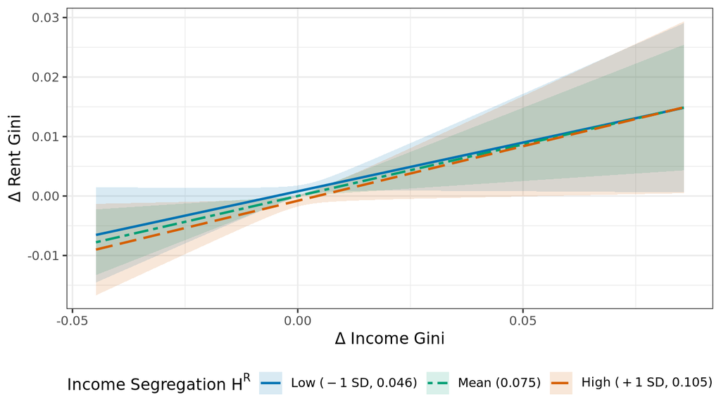

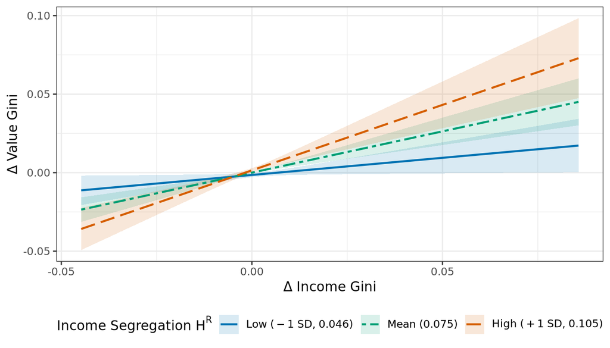

The FD results confirm the suspected asymmetry. The effect of a change in income inequality on housing cost inequality is positive and significant for both renters and owners. However, the effect is more than three times larger for owners compared to renters. The interaction effect for home values is substantially very large large and is significant at the one percent level, while the rent interaction is small and insignificant. Even the classic control variables that would indicate an increase in demand (population growth and the change in the unemployment rate) fail to achieve significance in the model for changes in rent Gini. The FD estimator identifies changes within metros over time, so the value result specifically says that in metros where income segregation was higher at the start of a period, a given increase in income inequality over that period translated into a larger widening of home value dispersion. This dynamic pattern fits the capitalisation story: rising top incomes bid up values in the premium (segregated) neighbourhoods disproportionately, while value floors in low-income areas are held up by durable housing stock. Rents, by contrast, adjust more slowly, dampening the within-metro, within-period translation.

## Value and Rent Segregation as Alternative Moderators

Three caveats apply. *Endogeneity:* value and rent segregation are conceptually closer to the outcome ($\Delta$Gini Housing, which is itself a composite of rent and value dispersion), so the moderator risks being partially constitutive of the outcome rather than an independent structural condition. *Proxy validity:* at $r = 0.77$, $H^R_\text{val}$ largely substitutes for $H^R_\text{inc}$; a consistent result confirms that the two measures are interchangeable operationalisations but does not provide independent validation of the theoretical mechanism. *Conceptual distance:* at $r = 0.47$, $H^R_\text{rent}$ captures substantial variance orthogonal to income segregation, making it a less defensible proxy for the theoretical construct. The checks are therefore best understood as alternative operationalisations rather than strict robustness tests.

|  | (1) | (2) | (3) | (4) | (5) | (6) |
| --- | --- | --- | --- | --- | --- | --- |
| ΔIncome Gini | 0.375*** | 0.367*** | 0.408*** | 0.400*** | 0.375*** | 0.369*** |
|  | (0.077) | (0.078) | (0.076) | (0.077) | (0.071) | (0.072) |
| Income Segregation Hᴿ (t−5, centred) | 0.018 | 0.025 |  |  |  |  |
|  | (0.020) | (0.020) |  |  |  |  |
| ΔPopulation | −0.110*** | −0.094*** | −0.111*** | −0.092*** | −0.110*** | −0.093*** |
|  | (0.013) | (0.014) | (0.012) | (0.014) | (0.013) | (0.014) |
| ΔUnemployment Rate | 0.236** | 0.242** | 0.235** | 0.241** | 0.237** | 0.241** |
|  | (0.073) | (0.074) | (0.074) | (0.075) | (0.074) | (0.075) |
| ΔHispanic Share | 0.160* | 0.070 | 0.159* | 0.072 | 0.165* | 0.076 |
|  | (0.074) | (0.079) | (0.071) | (0.077) | (0.075) | (0.080) |
| ΔMultigroup Racial Segregation H | 0.086+ | 0.078+ | 0.095* | 0.085+ | 0.079+ | 0.079+ |
|  | (0.046) | (0.046) | (0.046) | (0.047) | (0.045) | (0.046) |
| ΔIncome Gini × Hᴿ (t−5) | 6.490* | 6.586* |  |  |  |  |
|  | (2.761) | (2.771) |  |  |  |  |
| Home-Value Seg. ℍᴿ (t−5, centred) |  |  | 0.014* | 0.014* |  |  |
|  |  |  | (0.007) | (0.007) |  |  |
| ΔIncome Gini × ℍᴿᵥₐₗ (t−5) |  |  | 3.249** | 3.310** |  |  |
|  |  |  | (1.079) | (1.086) |  |  |
| Contract-Rent Seg. ℍᴿ (t−5, centred) |  |  |  |  | −0.001 | 0.012 |
|  |  |  |  |  | (0.009) | (0.009) |
| ΔIncome Gini × ℍᴿᵣᵉⁿᵗ (t−5) |  |  |  |  | 2.650* | 2.751* |
|  |  |  |  |  | (1.274) | (1.287) |
| Num.Obs. | 1135 | 1135 | 1135 | 1135 | 1135 | 1135 |
| R2 | 0.367 | 0.379 | 0.372 | 0.383 | 0.365 | 0.377 |
| FE: year | X | X | X | X | X | X |
| FE: census_division |  | X |  | X |  | X |

Standard errors clustered by metro area in parentheses.  
+ p < 0.1, * p < 0.05, ** p < 0.01, *** p < 0.001.